# Reduced-Rank Matrix Autoregressive Models:

A Medium N Approach

**Ivan Ricardo**

iu.ricardo@maastrichtuniversity.nl

Maastricht University

Alain Hecq

a.hecq@maastrichtuniversity.nl

Maastricht University

Ines Wilms

i.wilms@maastrichtuniversity.nl

Maastricht University

November 27, 2024

## Data Structures

#### Univariate $(y_t)$

$$\begin{bmatrix}
\bullet \\
\bullet \\
\bullet
\end{bmatrix}$$

#### Multivariate $(\mathbf{y}_t)$

$$\begin{bmatrix}
\bullet & \bullet & \bullet \\
\bullet & \bullet & \bullet \\
\bullet & \bullet & \bullet
\end{bmatrix}$$

#### Matrix-valued $(\mathbf{Y}_t)$

[figure not shown]

Examples of matrix-valued data:

- Economic indicators for different countries over time
- Different air pollutants for cities over time (Yuan et al. 2023)
- Employment data over different sectors for different U.S. States over time (Samadi and Billard 2024)

## Our Setting

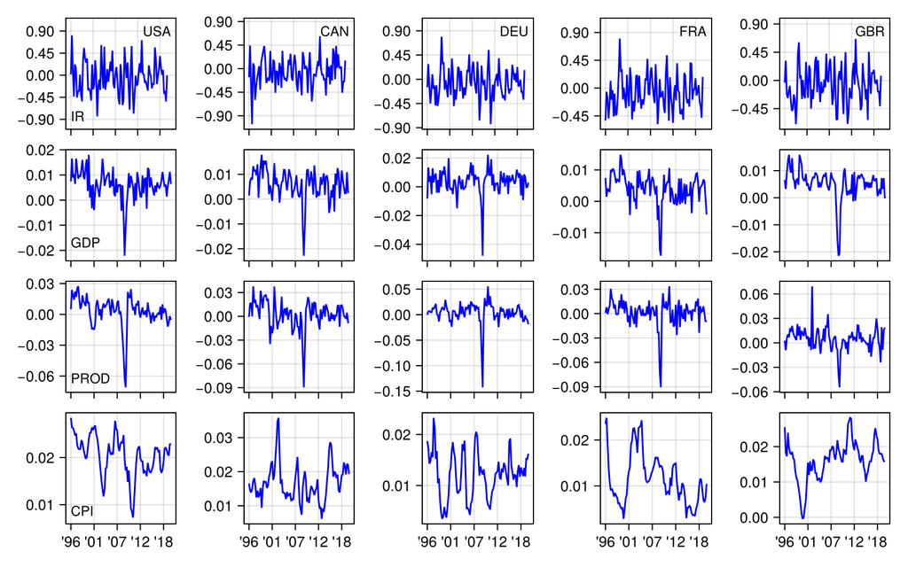

- We have $N_1 = 4$ economic indicators (Interest Rates, GDP, Industrial Production, CPI) over $N_2 = 5$ countries (USA, CAN, DEU, FRA, GBR)
- We are interested in whether there exists co-movements for the economic indicators and the countries **separately**

## Why Matrix-valued data?

- “Flattening” loses **dimension-specific interpretations**
- **Flexibility** in reduced-rank structures
- Allows for more **parsimonious models**

### Main Contributions:

- Introduce a flexible framework for modeling partial reduced-rank structures with varying ranks across dimensions
- Offer new insights into co-movements for each dimension of matrix-valued time series
- Relate co-movements to commonly used reduced-rank models: serial correlation common features (SCCF) and index/factor models

# Co-movements for Vector Valued Time Series

## VAR for multivariate/vector-valued time series

A standard Vector Autoregression (VAR) for vector-valued time series is
$$\mathbf{y}_t = \sum_{i=1}^p \mathbf{A}_i \mathbf{y}_{t-i} + \mathbf{e}_t,$$
with $\mathbf{A}_i \in \mathbb{R}^{N \times N}$ and $\mathbf{y}_t \in \mathbb{R}^{N}$

- We assume $\mathbf{A}_i$ has a **reduced rank** structure
- $\mathbf{A}_i$ is the product of two lower dimensional matrices, either $\mathbf{B} \mathbf{C}_i'$ (SCCF) or $\mathbf{B}_i \mathbf{C}'$ (Factor model), where $\mathbf{B}, \mathbf{C} \in \mathbb{R}^{N \times r}$
- The short-run dynamics, or reactions to economic cycles, share a common driver

## Common Features

- “A feature will be said to be common if a linear combination of the series fails to have the feature even though each of the series individually has the feature” Engle and Kozicki (1993)
- Focus on common **serial correlation** (SCCF) for multiple time series:
  $$\mathbf{y}_t = \sum_{i=1}^p \textcolor{red}{\mathbf{B}}
  \mathbf{C}_i'\mathbf{y}_{t-i} + \mathbf{e}_t, \quad \mathbf{A}_i =
  \textcolor{red}{\mathbf{B}} \mathbf{C}_i'$$
- Pre-multiplying $\mathbf{y}_t$ by $\mathbf{B}_\perp' \in \mathbb{R}^{(N-r) \times N}$ removes the serial correlation
  $$\mathbf{B}_\perp' \mathbf{y}_t = \underbrace{\mathbf{B}_\perp'
  \mathbf{e}_t}_{\mathbf{e}_t^*}$$

## How do we interpret this?

- Suppose we observe the GDP of three countries: United States (USA), Canada (CAN), and Great Britain (GBR)
- We estimate the SCCF model with $r = 1$ and, after rotation, find
  $$\mathbf{B}_\perp' = \begin{bmatrix}
  1 & 0 & -2 \\
  0 & 1 & -1 \\
  \end{bmatrix}$$

$$y_{t, usa} - 2 y_{t, gbr} = e_{t, 1}^* \quad \text{and} \quad y_{t, can} - y_{t, gbr} =
e_{t, 2}^*$$

- USA and GBR co-move contemporaneously, with USA moving twice as large as GBR
- CAN and GBR co-move, with CAN moving with GBR

## Index Models

$$\mathbf{y}_t = \sum_{i=1}^p \mathbf{B}_i \textcolor{red}{\mathbf{C}'}\mathbf{y}_{t-i} +
\mathbf{e}_t, \quad \mathbf{A}_i = \mathbf{B}_i \textcolor{red}{\mathbf{C}'}$$

- $\mathbf{C}' \mathbf{y}_{t-i}$ are the indices, or factors that summarize the information contained in $\mathbf{y}_{t-i}$
- $\mathbf{y}_t$ is driven by **lags** of factors
- Can be used for forecasting or structural analysis of high-dimensional time series

# Matrix Autoregressive Models

## Matrix Autoregressive Model (MAR)

For **matrix-valued** time series, we have the MAR(p) model
$$\mathbf{Y}_t = \sum_{i=1}^p \mathcal{A}_i \bar{\times}_2 \mathbf{Y}_{t-i} + \mathbf{E}_t,$$
where $\mathbf{Y}_t \in \mathbb{R}^{N_1 \times N_2}$, $\mathcal{A}_i \in \mathbb{R}^{N_1 \times N_2 \times N_1 \times N_2}$, and $\bar{\times}_2$ is the **contraction** along the second dimension

- Contraction is the generalization of matrix multiplication extended to **tensors**
- In our example, $N_1$ are economic indicators and $N_2$ are countries

Contraction Details

## Low Rank Structure

$$\mathbf{Y}_t = \sum_{i=1}^p \mathcal{A}_i \bar{\times}_2 \mathbf{Y}_{t-i} + \mathbf{E}_t$$

We assume $\mathcal{A}_i$ has a **Tucker decomposition** (Tucker 1966):
$$\mathcal{A}_i = \mathcal{G}_i \times_1 \mathbf{U}_{1} \times_2 \mathbf{U}_{2} \times_3
\mathbf{U}_{3} \times_4 \mathbf{U}_{4} \in \mathbb{R}^{N_1 \times N_2 \times N_1 \times
N_2},$$
$$\mathbf{U}_{1} \in \mathbb{R}^{N_1 \times r_1}, \quad \mathbf{U}_{2} \in \mathbb{R}^{N_2
\times r_2},$$
$$\mathbf{U}_{3} \in \mathbb{R}^{N_1 \times r_3}, \quad \mathbf{U}_{4} \in \mathbb{R}^{N_2
\times r_4},$$
$$\mathcal{G}_i \in \mathbb{R}^{r_1 \times r_2 \times r_3 \times r_4}$$

- $\mathbf{U}_j, j = 1, \dots, 4$ may have **different ranks**, and $\mathcal{G}_i$ ties it all together

## Tucker Decomposition

- Visualizations are limited to three-dimensional tensors (rather than our four dimensional coefficient)

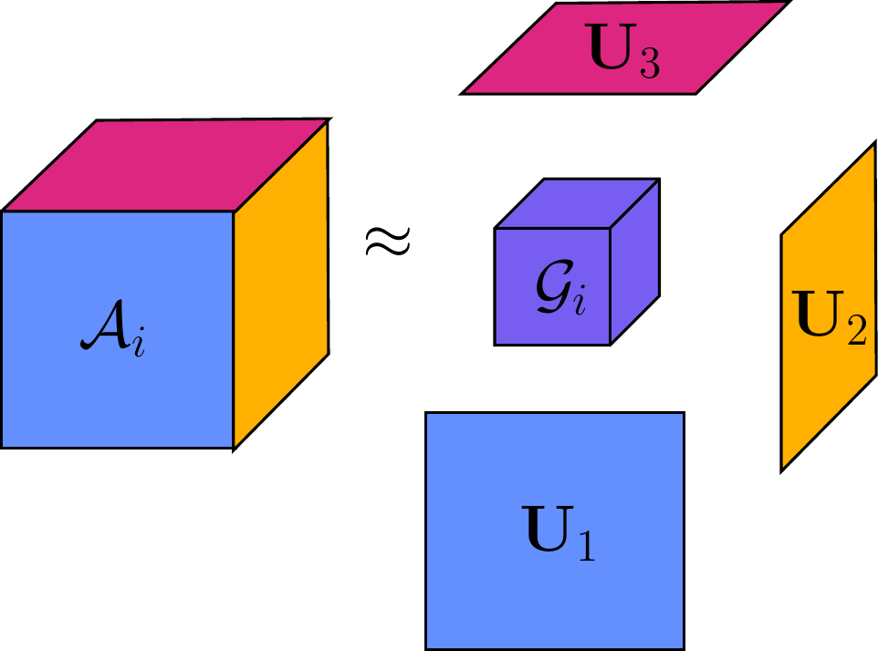

- $\mathcal{A}_i$ is decomposed into a “compressed” core tensor $\mathcal{G}_i$ and factor matrices $\mathbf{U}_j$ for $j = 1, \dots, 4$

## Equivalent VAR representation

- The Reduced Rank MAR(p) has an equivalent vectorized form, where $\text{vec}(\mathbf{Y}_t) = \mathbf{y}_t \in \mathbb{R}^{N_1 N_2}$ and $\text{mat}(\mathcal{A}_i) = \mathbf{A}_i \in \mathbb{R}^{N_1 N_2 \times N_1 N_2}$
  $$\mathbf{y}_t = \sum_{i=1}^p \underbrace{(\mathbf{U}_{2} \otimes \mathbf{U}_{1})
  \mathbf{G}_{i} (\mathbf{U}_{4} \otimes \mathbf{U}_{3})'}_{\mathbf{A}_i}
  \mathbf{y}_{t-i} + \mathbf{e}_t$$
- $\text{rank}(\mathbf{A}_i) = \min (r_1 r_2, r_3 r_4)$
- Allows us to explore both SCCF and index model restrictions

## Link to SCCF

- Our null space matrix from before ($\mathbf{A}_\perp$) now has a **Kronecker structure**
  $$\mathbf{y}_t = \sum_{i=1}^p \textcolor{red}{(\mathbf{U}_{2} \otimes \mathbf{U}_{1})}
  \mathbf{G}_{i} (\mathbf{U}_{4} \otimes \mathbf{U}_{3})' \mathbf{y}_{t-i} +
  \mathbf{e}_t$$
  $$(\mathbf{U}_{2} \otimes \mathbf{U}_{1})_\perp' \mathbf{y}_t = (\mathbf{U}_{2}
  \otimes \mathbf{U}_{1})_\perp' \mathbf{e}_t$$
- $\mathbf{U}_{1 \perp}$ and $\mathbf{U}_{2 \perp}$ contain information on the co-movements between **rows** and **columns** of $\mathbf{Y}_t$
- $r_1$ and $r_2$ are the SCCF ranks for the economic indicators or the countries

## Another Example

- We now observe the GDP and Industrial Production (PROD) of each country, with the same three countries as before: USA, CAN, and GBR
- Forms an $N_1 \times N_2 = 2 \times 3$ matrix-valued time series
- All countries co-move, and all economic indicators co-move, resulting in rank $(r_1 = 1,r_2 = 1)$ for the SCCF model
  $$\mathbf{U}_{1\perp}' = \begin{bmatrix}
  1 & -1
  \end{bmatrix}, \quad \mathbf{U}_{2\perp}' = \begin{bmatrix}
  1 & 0 & -2 \\
  0 & 1 & -1 \\
  \end{bmatrix}$$
  $$y_{t, gdp} - y_{t, prod} = e_{t}^*$$
  $$y_{t, usa} - 2 y_{t, gbr} = e_{t}^* \quad \text{and} \quad y_{t, can} - y_{t, gbr} =
  e_{t}^*$$
- We can **separate** the effects from the countries and the indicators

## Connection with VAR coefficient

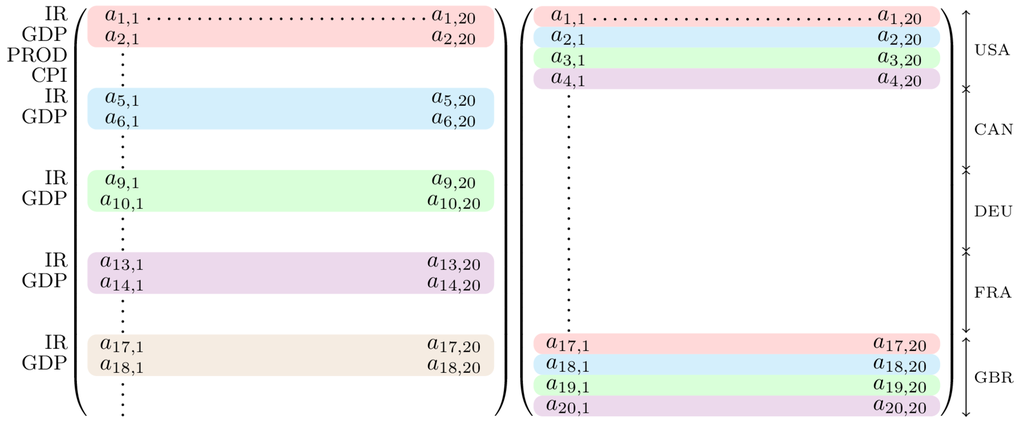

- Left illustrates a partial reduced rank of the indicators $r_1 = 3$ and $r_2 = N_2 = 5$
- Right illustrates a partial reduced rank of the countries $r_1 = N_1 = 4$ and $r_2 = 4$

## Index/Factor Models

$$\mathbf{y}_t = \sum_{i=1}^p (\mathbf{U}_{2} \otimes \mathbf{U}_{1}) \mathbf{G}_{i}
\textcolor{red}{(\mathbf{U}_{4} \otimes \mathbf{U}_{3})'} \mathbf{y}_{t-i} +
\mathbf{e}_t$$

Can be rearranged as

$$\mathbf{f}_t^{resp} = \sum_{i=1}^p \mathbf{G}_{i} \mathbf{f}_{t-i}^{pred} +
\mathbf{e}_t^*,$$
$$\mathbf{f}_t^{resp} = (\mathbf{U}_{2} \otimes \mathbf{U}_1)' \mathbf{y}_t \in
\mathbb{R}^{r_1 r_2}, \quad \mathbf{f}_{t-i}^{pred} = (\mathbf{U}_{4} \otimes
\mathbf{U}_3)' \mathbf{y}_{t-i} \in \mathbb{R}^{r_3 r_4}$$

- We now have “response” factors $\mathbf{f}_t$ and “predictor” factors $\mathbf{f}_{t-i}$ connected with the $\mathbf{G}_i$ autoregressive coefficient
- Large autoregression is driven by a small autoregression of factors

# Selection of Tucker Ranks

## Tucker Rank Selection

- Standard information criteria (AIC and BIC) to jointly estimate the ranks and lags

$$\small
\text{AIC}(r_1, r_2, r_3, r_4, p) = \ln(|\widehat{\Sigma}_{\mathbf{E}}|) + \frac{2}{T}
\phi(r_1, r_2, r_3, r_4, p),$$
$$\small
\text{BIC}(r_1, r_2, r_3, r_4, p) = \ln(|\widehat{\Sigma}_{\mathbf{E}}|) + \frac{\ln(T)}{T}
\phi(r_1, r_2, r_3, r_4, p),$$
where
$$\small
\phi(r_1, r_2, r_3, r_4, p) = \prod_{i=1}^{4} r_i p + \sum_{i=1}^2 (r_i (N_i - r_i) +
r_{2+i} (N_i - r_{2+i})),$$
is the number of parameters in the model

# Simulation Study

## Simulation Study

- Selecting Tucker ranks with AIC and BIC

| Setting | $N_1 \times N_2 = 3 \times 4$ |
| --- | --- |
| Fully Reduced | $\mathbf{r} = (1,1,1,1)$ |
| Partially Reduced (1st Dimension) | $\mathbf{r} = (3,1,3,1)$ |
| Partially Reduced (2nd Dimension) | $\mathbf{r} = (1,4,1,4)$ |
| No Rank Reduction | $\mathbf{r} = (3,4,3,4)$ |

## Fully reduced

### True rank of $\mathbf{r} = (1,1,1,1)$

| Method<sup>1</sup> | Average Rank | Standard Deviation | Freq. Correct |
| --- | --- | --- | --- |
| AIC (100) | (1.42, 1.43, 1.54, 1.60) | (0.71, 0.81, 0.78, 1.01) | (0.71, 0.72, 0.64, 0.69) |
| BIC (100) | (1.01, 1.00, 1.01, 1.00) | (0.12, 0.00, 0.11, 0.00) | (0.99, 1.00, 0.99, 1.00) |
| AIC (500) | (1.35, 1.31, 1.42, 1.41) | (0.67, 0.72, 0.71, 0.87) | (0.76, 0.80, 0.71, 0.78) |
| BIC (500) | (1.00, 1.00, 1.00, 1.00) | (0.00, 0.00, 0.00, 0.00) | (1.00, 1.00, 1.00, 1.00) |

[^1]: Defined as the information criteria and number of observations (either 100 or 500)

## Partially reduced first dimension

### True rank of $\mathbf{r} = (3,1,3,1)$

| Method | Average Rank | Standard Deviation | Freq. Correct |
| --- | --- | --- | --- |
| AIC (100) | (3.00, 1.04, 3.00, 1.11) | (0.00, 0.22, 0.00, 0.40) | (1.00, 0.96, 1.00, 0.91) |
| BIC (100) | (3.00, 1.00, 3.00, 1.00) | (0.00, 0.00, 0.00, 0.00) | (1.00, 1.00, 1.00, 1.00) |
| AIC (500) | (3.00, 1.01, 3.00, 1.04) | (0.00, 0.10, 0.00, 0.23) | (1.00, 0.99, 1.00, 0.96) |
| BIC (500) | (3.00, 1.00, 3.00, 1.00) | (0.00, 0.00, 0.00, 0.00) | (1.00, 1.00, 1.00, 1.00) |

## Partially reduced second dimension

### True rank of $\mathbf{r} = (1,4,1,4)$

| Method | Average Rank | Standard Deviation | Freq. Correct |
| --- | --- | --- | --- |
| AIC (100) | (1.01, 4.00, 1.05, 4.00) | (0.10, 0.00, 0.25, 0.00) | (0.99, 1.00, 0.96, 1.00) |
| BIC (100) | (1.00, 4.00, 1.00, 4.00) | (0.00, 0.00, 0.00, 0.00) | (1.00, 1.00, 1.00, 1.00) |
| AIC (500) | (1.00, 4.00, 1.02, 4.00) | (0.04, 0.00, 0.15, 0.00) | (0.99, 1.00, 0.98, 1.00) |
| BIC (500) | (1.00, 4.00, 1.00, 4.00) | (0.00, 0.00, 0.00, 0.00) | (1.00, 1.00, 1.00, 1.00) |

## No rank reduction

### True rank of $\mathbf{r} = (3,4,3,4)$

| Method | Average Rank | Standard Deviation | Freq. Correct |
| --- | --- | --- | --- |
| AIC (100) | (3.00, 4.00, 3.00, 4.00) | (0.00, 0.00, 0.00, 0.00) | (1.00, 1.00, 1.00, 1.00) |
| BIC (100) | (3.00, 4.00, 3.00, 4.00) | (0.00, 0.00, 0.00, 0.00) | (1.00, 1.00, 1.00, 1.00) |
| AIC (500) | (3.00, 4.00, 3.00, 4.00) | (0.00, 0.00, 0.00, 0.00) | (1.00, 1.00, 1.00, 1.00) |
| BIC (500) | (3.00, 4.00, 3.00, 4.00) | (0.00, 0.00, 0.00, 0.00) | (1.00, 1.00, 1.00, 1.00) |

# Applications

## Macroeconomic indicators for various countries

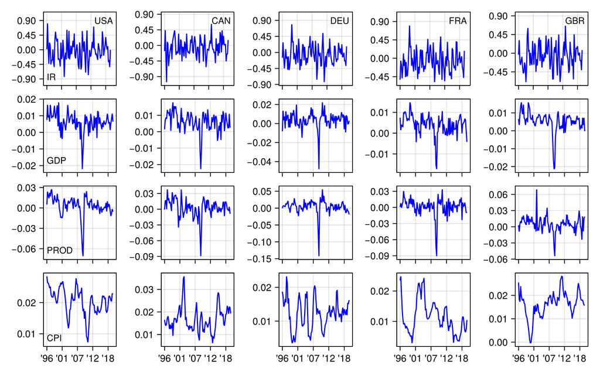

- AIC selects a rank of $(4,5,4,5)$ with three lags, while BIC selects a rank of $(3,1,4,3)$ with one lag
- Contemporaneous co-movements between indicators and countries
- Factors are driven by countries, full rank for indicators

## Serial Correlation Common Features

- $(r_1=3,r_2=1)$ implies a partially reduced economic indicator dimension, while the country dimension is fully reduced

### Economic Indicators

- Rank of $r_1=3$: one co-movement relation between all four indicators
- Normalizing over the second variables (GDP), we obtain

| Indicator |  |
| --- | --- |
| **IR** | 0.0001 |
| **GDP** | 1 |
| **PROD** | -0.3331 |
| **CPI** | 0.1194 |

## Serial Correlation Common Features

### Countries

- Rank of $r_2=1$: all countries co-move contemporaneously
- If we are interested in the co-movements of the U.S., we normalize the null space matrix accordingly

| Country |  |  |  |  |  |
| --- | --- | --- | --- | --- | --- |
| **USA** | -0.85 | -0.74 | -0.79 | -0.77 |  |
| **CAN** | 1.00 | 0.00 | 0.00 | 0.00 |  |
| **DEU** | 0.00 | 1.00 | 0.00 | 0.00 |  |
| **FRA** | 0.00 | 0.00 | 1.00 | 0.00 |  |
| **GBR** | 0.00 | 0.00 | 0.00 | 1.00 |  |

- Almost one-to-one co-movements of all countries with the U.S., with the Canadian economic indicators most closely moving together with the U.S. ones, as evident from the first column

## Factor Models

- $(r_3=4,r_4=3)$ implies a full rank indicator dimension, while the country dimension is partially reduced
- We construct predictor factors $\mathbf{F}_t^{pred} = \mathbf{U}_3^\top \mathbf{Y}_{t-1} \mathbf{U}_4 \in \mathbb{R}^{4 \times 3}$

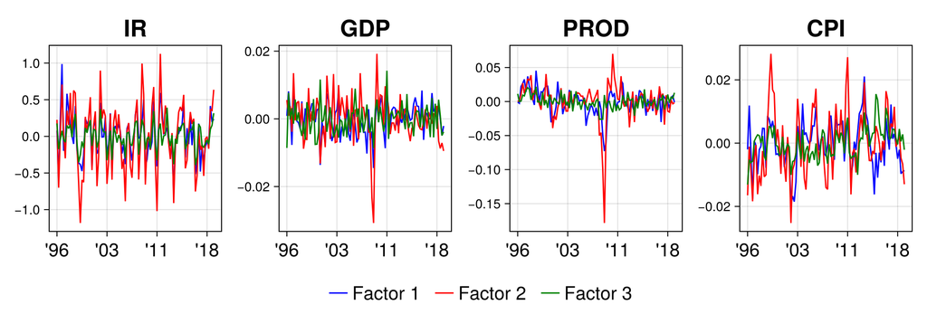

## Conclusion

- RR-MAR captures dimension-specific co-movement dynamics in matrix time series at aggregate levels
- Uncovers contemporaneous and lagged relationships for fully/partially reduced rank structures
- Co-movements identified for all countries and strongest for GDP/PROD

#### Arxiv

[figure not shown]

#### Reproduction

[figure not shown]

#### Package

[figure not shown]

## Matricization/Unfolding

For any $K$-dimensional tensor $\mathcal{Y} \in \mathbb{R}^{N_1 \times \dots \times N_K}$, denote its mode-$k$ unfolding $\mathbf{Y}_{(k)} \in \mathbb{R}^{N_k \times N_{-k}}$, with $N_{-k}:= \prod_{i = 1, i \neq k}^K N_i$, as the matrix obtained by setting the $k$-th tensor mode as its rows and collapsing all the other dimensions into the columns. Specifically, the $(n_1, \dots, n_K)$-th element of $\mathcal{Y}$ is mapped to the $(n_k, j)$-element of $\mathbf{Y}_{(k)}$, where

$$j = 1 + \sum_{\substack{l = 1,\\l \neq k}}^K (n_l - 1) J_l \quad \text{with} \quad J_l =
\prod_{\substack{m = 1,\\m \neq k}}^{l - 1} N_m.$$

## Examples

Let the frontal slices of a tensor $\mathcal{X} \in \mathbb{R}^{3 \times 4 \times 2}$ be as follows
$$\scriptsize
\begin{align*}
\mathcal{X} = \left[
\begin{bmatrix}
1 & 4 & 7 & 10 \\
2 & 5 & 8 & 11 \\
3 & 6 & 9 & 12
\end{bmatrix},
\begin{bmatrix}
13 & 16 & 19 & 22 \\
14 & 17 & 20 & 23 \\
15 & 18 & 21 & 24
\end{bmatrix}\right]
\end{align*}$$
The three mode-$n$ unfoldings are:
$$\scriptsize
\begin{gather*}
\mathbf{X}_{(1)} = \begin{bmatrix}
1 & 4 & 7 & 10 & 13 & 16 & 19 & 22 \\
2 & 5 & 8 & 11 & 14 & 17 & 20 & 23 \\
3 & 6 & 9 & 12 & 15 & 18 & 21 & 24
\end{bmatrix} \quad
\mathbf{X}_{(2)} = \begin{bmatrix}
1 & 2 & 3 & 13 & 14 & 15 \\
4 & 5 & 6 & 16 & 17 & 18 \\
7 & 8 & 9 & 19 & 20 & 21 \\
10 & 11 & 12 & 22 & 23 & 24
\end{bmatrix} \\
\mathbf{X}_{(3)} = \begin{bmatrix}
1 & 2 & 3 & 4 & 5 & \dots & 9 & 10 & 11 & 12 \\
13 & 14 & 15 & 16 & 17 & \dots & 21 & 22 & 23 & 24
\end{bmatrix}
\end{gather*}$$
Back to main

## Contraction

The mode-n product between a tensor $\mathcal{X} \in \mathbb{R}^{I_1 \times I_2 \times \dots \times I_N}$ and a matrix $\mathbf{U} \in \mathbb{R}^{J \times I_n}$ is then denoted
$$\small
\begin{align*}
(\mathcal{X} \times_{n} \mathbf{U})_{i_1, \dots, i_{n-1}, j, i_{n+1}, \dots, i_N} =
\sum_{i_n = 1}^{I_n} x_{i_1, i_2, \dots, i_N} u_{j, i_n} \in
\mathbb{R}^{I_1 \times \dots \times I_{n-1} \times J \times I_{n+1} \times \dots \times I_N}
\end{align*}$$

This can also be expressed in terms of unfolded tensors as
$$\begin{equation*}
\small
\mathcal{Y} = \mathcal{X} \times_{n} \mathbf{U} \quad \Leftrightarrow \quad \mathbf{Y}_{(n)}
= \mathbf{U} \mathbf{X}_{(n)}
\end{equation*}$$

## Contraction

Suppose we have $\mathcal{X} \in \mathbb{R}^{I_1 \times \dots \times I_M}$ and $\mathcal{Y} \in \mathbb{R}^{J_1 \times \dots \times J_N}$ with $I_m = J_1$. The sequence of contracted products is denoted by $\mathcal{X} \bar{\times}_{M} \mathcal{Y}$ and yields a $(M+N-2)$ order tensor $\mathcal{Z} \in \mathbb{R}^{I_1 \times \dots \times I_{M-1} \times J_1 \times \dots \times J_{N-1}}$ with entries
$$\small
\begin{align*}
\mathcal{Z}_{i_1, \dots, I_{M-1}, j_2, \dots, j_N} = (\mathcal{X} \times_{M}
\mathcal{Y})_{i_1, \dots, i_{M-1}, j_2, \dots, j_N} = \sum_{i_M = 1}^{I_M} \mathcal{X}_{i_1,
\dots, i_{M-1}, i_M} \mathcal{Y}_{i_M, j_2, \dots, j_N}
\end{align*}$$
If we have a $5 \times 4 \times 3 \times 2$ tensor $\mathcal{A}$ and a $3 \times 2$ matrix $\mathbf{B}$, the sequence of contractions yields the matrix
$$\small
\mathcal{A} \bar{\times}_2 \mathbf{B} = \mathbf{C} \in \mathbb{R}^{5 \times 4}$$

Back to main

## Fully reduced

### True rank of $\mathbf{r} = (1,1,1,1)$

| Method | Average Rank | Standard Deviation | Freq. Correct |
| --- | --- | --- | --- |
| AIC (100) | (1.25, 1.08, 1.25, 1.16) | (0.43, 0.38, 0.43, 0.85) | (0.75, 0.94, 0.75, 0.94) |
| BIC (100) | (1.06, 1.00, 1.06, 1.00) | (0.24, 0.00, 0.24, 0.00) | (0.94, 1.00, 0.94, 1.00) |
| AIC (500) | (1.18, 1.07, 1.19, 1.06) | (0.39, 0.30, 0.39, 0.29) | (0.82, 0.94, 0.81, 0.95) |
| BIC (500) | (1.01, 1.00, 1.01, 1.00) | (0.09, 0.00, 0.09, 0.00) | (0.99, 1.00, 0.99, 1.00) |

## Partially reduced first dimension

### True rank of $\mathbf{r} = (1,9,1,9)$

| Method | Average Rank | Standard Deviation | Freq. Correct |
| --- | --- | --- | --- |
| AIC (100) | (1.00, 8.97, 1.00, 8.97) | (0.00, 0.19, 0.04, 0.19) | (1.00, 0.97, 1.00, 0.98) |
| BIC (100) | (1.00, 8.71, 1.00, 8.71) | (0.00, 0.65, 0.00, 0.65) | (1.00, 0.82, 1.00, 0.82) |
| AIC (500) | (1.00, 9.00, 1.00, 9.00) | (0.00, 0.00, 0.00, 0.00) | (1.00, 1.00, 1.00, 1.00) |
| BIC (500) | (1.00, 8.99, 1.00, 8.99) | (0.00, 0.09, 0.00, 0.09) | (1.00, 0.99, 1.00, 0.99) |

## Partially reduced second dimension

### True rank of $\mathbf{r} = (2,1,2,1)$

| Method | Average Rank | Standard Deviation | Freq. Correct |
| --- | --- | --- | --- |
| AIC (100) | (2.00, 1.11, 2.00, 1.18) | (0.00, 0.43, 0.00, 0.81) | (1.00, 0.93, 1.00, 0.92) |
| BIC (100) | (2.00, 1.00, 2.00, 1.00) | (0.00, 0.00, 0.00, 0.00) | (1.00, 1.00, 1.00, 1.00) |
| AIC (500) | (2.00, 1.06, 2.00, 1.08) | (0.00, 0.31, 0.00, 0.36) | (1.00, 0.95, 1.00, 0.94) |
| BIC (500) | (2.00, 1.00, 2.00, 1.00) | (0.00, 0.00, 0.00, 0.00) | (1.00, 1.00, 1.00, 1.00) |

## No rank reduction

### True rank of $\mathbf{r} = (2,9,2,9)$

| Method | Average Rank | Standard Deviation | Freq. Correct |
| --- | --- | --- | --- |
| AIC (100) | (2.00, 9.00, 2.00, 9.00) | (0.00, 0.00, 0.00, 0.00) | (1.00, 1.00, 1.00, 1.00) |
| BIC (100) | (2.00, 8.83, 2.00, 8.58) | (0.00, 0.38, 0.00, 0.65) | (1.00, 0.83, 1.00, 0.67) |
| AIC (500) | (2.00, 9.00, 2.00, 9.00) | (0.00, 0.00, 0.00, 0.00) | (1.00, 1.00, 1.00, 1.00) |
| BIC (500) | (2.00, 9.00, 2.00, 9.00) | (0.00, 0.00, 0.00, 0.00) | (1.00, 1.00, 1.00, 1.00) |

## Estimation by Least Squares

$$\small
\begin{flalign*}
\widehat{\mathcal{A}} &= [[\widehat{\mathcal{G}}; \widehat{\mathbf{U}}_1,
\widehat{\mathbf{U}}_2, \widehat{\mathbf{U}}_3, \widehat{\mathbf{U}}_4]] = &&
\end{flalign*}$$
$$\small \underset{\substack{\mathcal{G} \in \mathbb{R}^{r_1 \times r_2 \times r_3 \times
r_4},\\ \mathbf{U}_{i} \in \mathbb{R}^{N_j \times r_i}}}{\arg\min} \left\{
\frac{1}{2T}\sum_{t=1}^T \|\text{vec}(\mathbf{Y}_t) - \left(\mathbf{U}_2 \otimes
\mathbf{U}_1\right) \mathbf{G}_{[2]} \left( \mathbf{I}_p \otimes \mathbf{U}_4 \otimes
\mathbf{U}_3\right)^\top \text{vec}(\mathcal{X}_{t})\|_F^2\right\},$$

- Rearrange the lags into a separate dimension to make $\mathcal{X}_t$
- Non-convex optimization problem as with many reduced rank problems
- Use an alternating gradient descent scheme to solve

## Projection Matrices

- Projection matrices $\mathbf{U}_i \mathbf{U}_i'$ are **exactly identified**
- Tell us which variables are most important for each factor

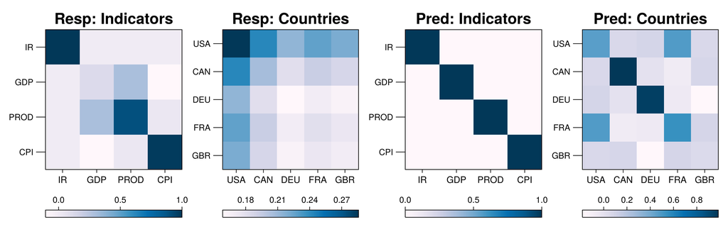

## Coincident and Leading Indexes for U.S. States

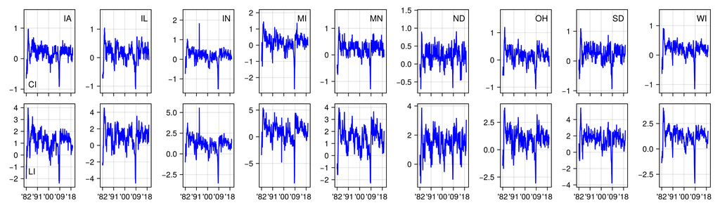

- Consider $N_1 = 2$ indicators (coincident and leading) over $N_2 = 9$ states: Iowa (IA), Illinois (IL), Indiana (IN), Michigan (MI), Minnesota (MN), North Dakota (ND), Ohio(OH), South Dakota (SD), and Wisconsin (WI)
- Coincident and Leading Indicators may not move with one another, but different states may co-move

## Coincident and Leading Indexes for U.S. States

- AIC selects full rank with two lags, while BIC selects full rank with one lag
- Results suggest no evidence for co-movements among the indicators or the states
- Highlight the potential for identifying no rank reduction in the data

## References

Engle, Robert F., and Sharon Kozicki. 1993. “Testing for Common Features.” *Journal of Business & Economic Statistics* 11 (4): 369–80. https://doi.org/10.1080/07350015.1993.10509966.

Samadi, S. Yaser, and Lynne Billard. 2024. “On a Matrix-Valued Autoregressive Model.” *Journal of Time Series Analysis*. https://onlinelibrary.wiley.com/doi/abs/10.1111/jtsa.12748.

Tucker, Ledyard R. 1966. “Some Mathematical Notes on Three-Mode Factor Analysis.” *Psychometrika* 31 (3): 279–311.

Yuan, Chaofeng, Zhigen Gao, Xuming He, Wei Huang, and Jianhua Guo. 2023. “Two-way dynamic factor models for high-dimensional matrix-valued time series.” *Journal of the Royal Statistical Society Series B: Statistical Methodology* 85 (5): 1517–37. https://doi.org/10.1093/jrsssb/qkad077.